# Preceptor Participation Suvery Results

```r
library(readr)
responses <- read_csv("responses.csv")
comments <- read_csv("comments.csv")
```

**Number of responses: 19**

### Which of the following do you feel are barriers to precepting resident research projects?

1. Disagree with processes of research subcommittee
2. Intimidated by degree of involvement
3. No perceived benefit for clinical ladder advancement
4. No protected work time for residency projects
5. No research ideas
6. Not interested in precepting projects

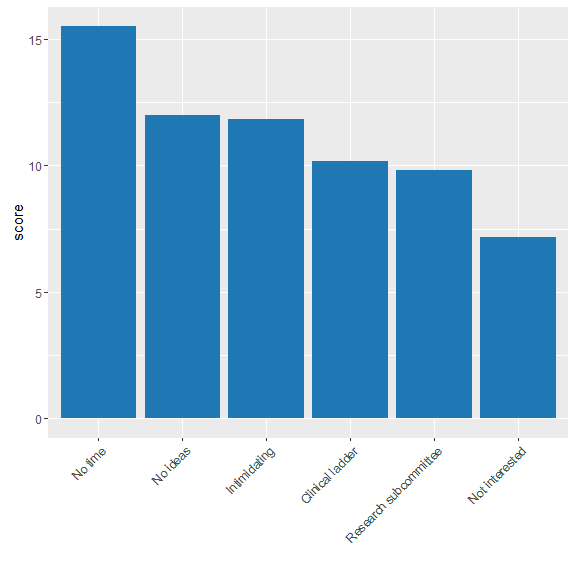

```r
suppressPackageStartupMessages(library(dplyr))
library(stringr)
library(ggplot2)
ans <- c("Disagree with processes of research subcommittee" = "Research subcommittee",
         "Intimidated by degree of involvement" = "Intimidating",
         "No perceived benefit for clinical ladder advancement" = "Clinical ladder",
         "No protected work time for residency projects" = "No time",
         "No research ideas" = "No ideas",
         "Not interested in precepting projects" = "Not interested")
results <- filter(responses, question == 1) %>%
    mutate(score = (7 - rank) / 6,
           option = str_replace_all(option, ans)) %>%
    group_by(option) %>%
    summarize(score = sum(score)) %>%
    arrange(desc(score))

ggplot(results, aes(x = ordered(option, levels = results$option), y = score)) +
    geom_bar(stat = "identity", fill = "#1F78B4") +
    xlab("") +
    theme(axis.text.x = element_text(angle = 45, hjust = 1))
```

#### Comments

```r
d <- filter(comments, question == 1)
library(pander)
pander(as.list(d$comment))
```

- No perceived benefit to our practice, the department, and MH
- 1. Ability to extract reliable data independently. 2. Statistics - understanding statistical applications, access to SPSS and knowing how to use it.
- Availability to obtain patient list and data for the resident.
- lack of department computer support for data management
- I think the biggest problem for the residency program is the research subcommittee. Here are the problems: Lack of effective mentorship; Lacks the focus on what the clear goal are for the residents research program; Lacks intellectual discussion; I recommend adding more experienced person, such as Judith Smith or even considering outside member of health care ( physicians) with research background
- Obtaining data is difficult (pt lists)
- too many steps and people involved in residency research projects

### Which of the following do you feel are barriers to attending resident presentations (short topic, seminar, and case)?

1. Patient care responsibilities
2. No perceived benefit for my position or career ladder advancement
3. Not interested in residency activities
4. Schedule conflicts with other meetings
5. Topics are not interesting

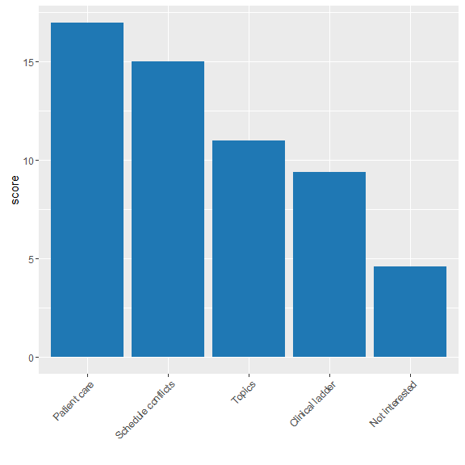

```r
ans <- c("Patient care responsibilities" = "Patient care",
         "No perceived benefit for my position or career ladder advancement" = "Clinical ladder",
         "Topics are not interesting" = "Topics",
         "Schedule conflicts with other meetings" = "Schedule conflicts",
         "Not interested in residency activities" = "Not interested")
results <- filter(responses, question == 2) %>%
    mutate(score = (6 - rank) / 5,
           option = str_replace_all(option, ans)) %>%
    group_by(option) %>%
    summarize(score = sum(score)) %>%
    arrange(desc(score))

ggplot(results, aes(x = ordered(option, levels = results$option), y = score)) +
    geom_bar(stat = "identity", fill = "#1F78B4") +
    xlab("") +
    theme(axis.text.x = element_text(angle = 45, hjust = 1))
```

#### Comments

```r
d <- filter(comments, question == 2)
pander(as.list(d$comment))
```

- It would be helpful if: 1. Reminder emails with attached articles went out earlier to facilitate reading articles 2. The reminder emails contained calendar invitations so the presentations show up in my schedule
- Work load is too great and competing projects
- Generally it is an issue of time. I can’t attend journal clubs, all presentations, precept rotations, and precept research without sometime to do actual work (patient care, mpps, quality work, etc).
- not focused to clinical areas

### Which of the following would be most likely to increase your desire to participate in residency projects and presentations?

1. Merit-based salary increase
2. Travel reimbursement for educational conference(s)
3. Reimbursement for other educational expenditures (e.g., computer software, certification course, textbooks)
4. Decreased number of student rotations to offset time spent on residency activities

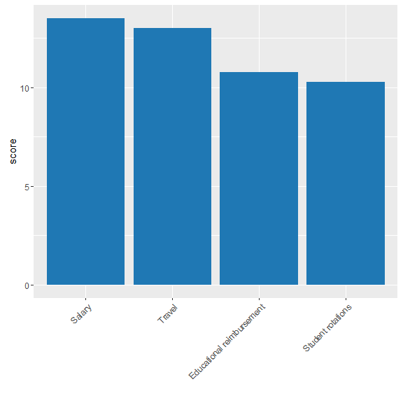

```r
ans <- c("Merit-based salary increase" = "Salary",
         "Travel reimbursement for educational conferences" = "Travel",
         "Reimbursement for other educational expenditures" = "Educational reimbursement",
         "Decreased number of student rotations to offset time spent on residency activities" = "Student rotations")
results <- filter(responses, question == 3) %>%
    mutate(score = (5 - rank) / 4,
           option = str_replace_all(option, ans)) %>%
    group_by(option) %>%
    summarize(score = sum(score)) %>%
    arrange(desc(score))

ggplot(results, aes(x = ordered(option, levels = results$option), y = score)) +
    geom_bar(stat = "identity", fill = "#1F78B4") +
    xlab("") +
    theme(axis.text.x = element_text(angle = 45, hjust = 1))
```

#### Comments

```r
d <- filter(comments, question == 3)
pander(as.list(d$comment))
```

- Increased outreach and engagement of all preceptors in the residency program. More one on one or service line based meetings between residency leadership and preceptor(s) to develop presentation and research ideas
- Making sure ideas are feasible/inline with RPD expectations prior to the resident’s choosing the activity topic/preceptor - maybe a group brainstorming session or examples of past topics for that activity to make expectation known. If possible, decrease student/ resident rotations when working on a time-consuming activity like a resident research project.
- Less stringent criteria, better transparency and expectation from the research committee. The PI of the research should reserve the right and final saying on the project and committee should refrain from setting final approval.
- increase acceptance of ideas